# Clase 9. Aplicacion ARIMA(p, d, q) y ARMA(p, q)

Benjamin Oliva & Omar Alfaro-Rivera

02/10/2023

# Importamos Datos:

Los datos importados son:

- Pax_Nal: Pasajeros (Salidas) en vuelos nacionales
- Pax_Int: Pasajeros (Salidas) en vuelos internacionales
- Vue_Nal: Vuelos u operaciones (Salidas) en vuelos nacionales
- Vue_Int: Vuelos u operaciones (Salidas) en vuelos internacionales
- Pax_Metro: Pasajeros transportados (Millones) en el SCM
- D_Sep2017: Dummy que toma el valor de 1 en septiembre de 2017
- D_Oct2017: Dummy que toma el valor de 1 en octubre de 2017
- D_Feb2020: Dummy que toma el valor de 1 en febrero de 2020
- D_Mar2020: Dummy que toma el valor de 1 en marzo de 2020
- D_Abr2020: Dummy que toma el valor de 1 en abril de 2020
- D_May2020: Dummy que toma el valor de 1 en mayo de 2020
- D_Jun2020: Dummy que toma el valor de 1 en junio de 2020
- D_Jul2020: Dummy que toma el valor de 1 en julio de 2020
- D_Ene2021: Dummy que toma el valor de 1 en enero de 2021
- D_Mar2021: Dummy que toma el valor de 1 en marzo de 2021
- D_Ene: Dummy que toma el valor de 1 en todos los eneros
- D_Dic: Dummy que toma el valor de 1 en todos los diciembres

Fuente: INEGI, https://www.inegi.org.mx/app/indicadores/?tm=0&t=1090

```r
Datos <- read_excel("Base_Transporte_ARIMA.xlsx", sheet = "Datos", col_names = TRUE)

tail(Datos)
```

```
## # A tibble: 6 × 22
##   Periodo             Pax_Nal Pax_Int Vue_Nal Vue_Int Pax_Metro D_Sep2017
##   <dttm>                <dbl>   <dbl>   <dbl>   <dbl>     <dbl>     <dbl>
## 1 2022-12-01 00:00:00 5456045 2709516   39644   17827      90.0         0
## 2 2023-01-01 00:00:00 5058367 2533314   38226   17747      87.3         0
## 3 2023-02-01 00:00:00 4515723 2277995   33571   15756      86.7         0
## 4 2023-03-01 00:00:00 5287795 2555185   37190   17796      99.4         0
## 5 2023-04-01 00:00:00 5428414 2302621   37443   16325      86.6         0
## 6 2023-05-01 00:00:00 5351191 2161952   37841   15519      96.5         0
## # ℹ 15 more variables: D_Oct2017 <dbl>, D_Feb2020 <dbl>, D_Mar2020 <dbl>,
## #   D_Abr2020 <dbl>, D_May2020 <dbl>, D_Jun2020 <dbl>, D_Jul2020 <dbl>,
## #   D_Ene2021 <dbl>, D_Mar2021 <dbl>, D_Ene <dbl>, D_Feb <dbl>, D_Jul <dbl>,
## #   D_Dic <dbl>, D_Ene2022 <dbl>, D_Feb2022 <dbl>
```

# Funciones que extrae y grafica las raices del polinomio caracteristico

```r
source("arroots.R")
source("maroots.R")
source("plot.armaroots.R")
```

# Conversion a series de tiempo:

```r
Pax_Nal <- ts(Datos$Pax_Nal,
              start = c(2000, 1),
              freq = 12)

LPax_Nal <- ts(log(Datos$Pax_Nal),
               start = c(2000, 1),
               freq = 12)

DLPax_Nal <- ts(log(Datos$Pax_Nal) - lag(log(Datos$Pax_Nal), 1),
                start = c(2000, 1),
                freq = 12)

D_Feb2020   <- ts(Datos$D_Feb2020,
                start = c(2000, 1),
                freq = 12)

D_Mar2020   <- ts(Datos$D_Mar2020,
                start = c(2000, 1),
                freq = 12)

D_Abr2020   <- ts(Datos$D_Abr2020,
                start = c(2000, 1),
                freq = 12)

D_May2020   <- ts(Datos$D_May2020,
                start = c(2000, 1),
                freq = 12)

D_Jun2020   <- ts(Datos$D_Jun2020,
                start = c(2000, 1),
                freq = 12)

D_Jul2020 <- ts(Datos$D_Jul2020,
                start = c(2000, 1),
                freq = 12)

D_Ene2021 <- ts(Datos$D_Ene2021,
                start = c(2000, 1),
                freq = 12)

D_Mar2021 <- ts(Datos$D_Mar2021,
                start = c(2000, 1),
                freq = 12)

D_Ene <- ts(Datos$D_Ene,
            start = c(2000, 1),
            freq = 12)

D_Feb <- ts(Datos$D_Feb,
            start = c(2000, 1),
            freq = 12)

D_Jul <- ts(Datos$D_Jul,
            start = c(2000, 1),
            freq = 12)

D_Dic <- ts(Datos$D_Dic,
            start = c(2000, 1),
            freq = 12)

D_Ene2022 <- ts(Datos$D_Ene2022,
                start = c(2000, 1),
                freq = 12)

D_Feb2022 <- ts(Datos$D_Feb2022,
                start = c(2000, 1),
                freq = 12)
```

# Graficas:

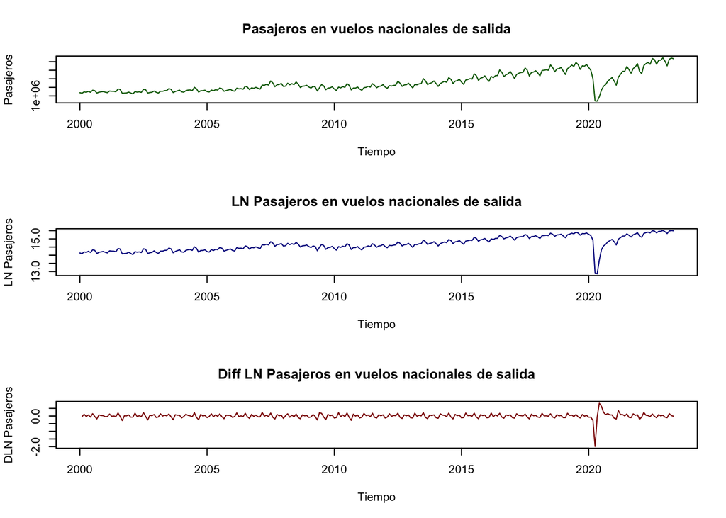

# Estimacion de ARIMA(1, 1, 1)

```r
ARMA_DLPax_Nal <- arima(DLPax_Nal, order = c(1, 0, 1),
                        xreg = cbind(D_Ene, D_Feb, D_Jul, D_Dic),
                        method = "ML")

ARMA_DLPax_Nal
```

```
##
## Call:
## arima(x = DLPax_Nal, order = c(1, 0, 1), xreg = cbind(D_Ene, D_Feb, D_Jul, D_Dic),
##     method = "ML")
##
## Coefficients:
##           ar1     ma1  intercept    D_Ene    D_Feb   D_Jul   D_Dic
##       -0.5679  0.8070     0.0032  -0.0983  -0.1212  0.1821  0.0624
## s.e.   0.1033  0.0676     0.0129   0.0356   0.0362  0.0324  0.0348
##
## sigma^2 estimated as 0.02413:  log likelihood = 124.01,  aic = -232.02
```

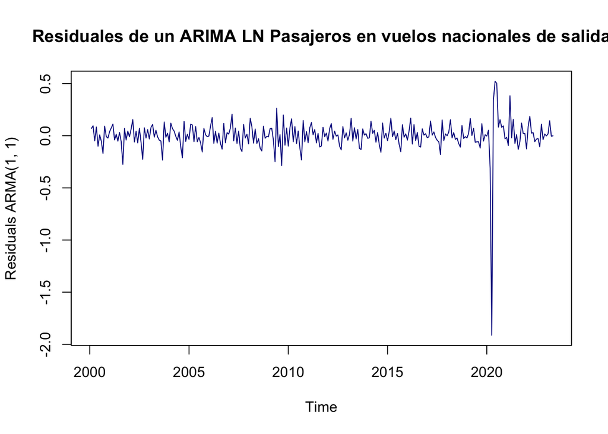

```r
#

plot(ARMA_DLPax_Nal$residuals,
     main = "Residuales de un ARIMA LN Pasajeros en vuelos nacionales de salida",
     col = "darkblue",
     ylab = "Residuals ARMA(1, 1)")
```

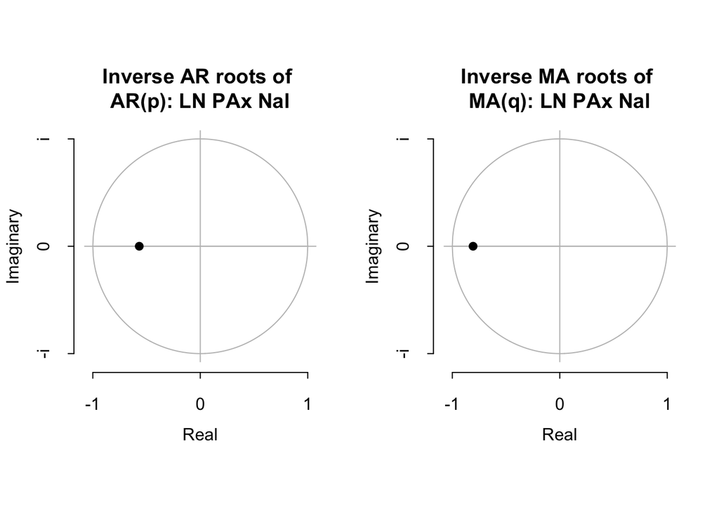

```r
#

par(mfrow=c(1,2))

plot.armaroots(arroots(ARMA_DLPax_Nal),
               main="Inverse AR roots of \nAR(p): LN PAx Nal")

plot.armaroots(maroots(ARMA_DLPax_Nal),
               main="Inverse MA roots of \nMA(q): LN PAx Nal")
```

```r
par(mfrow=c(1,1))
```

# Gráficas de las funciones de Autocorrelacion:

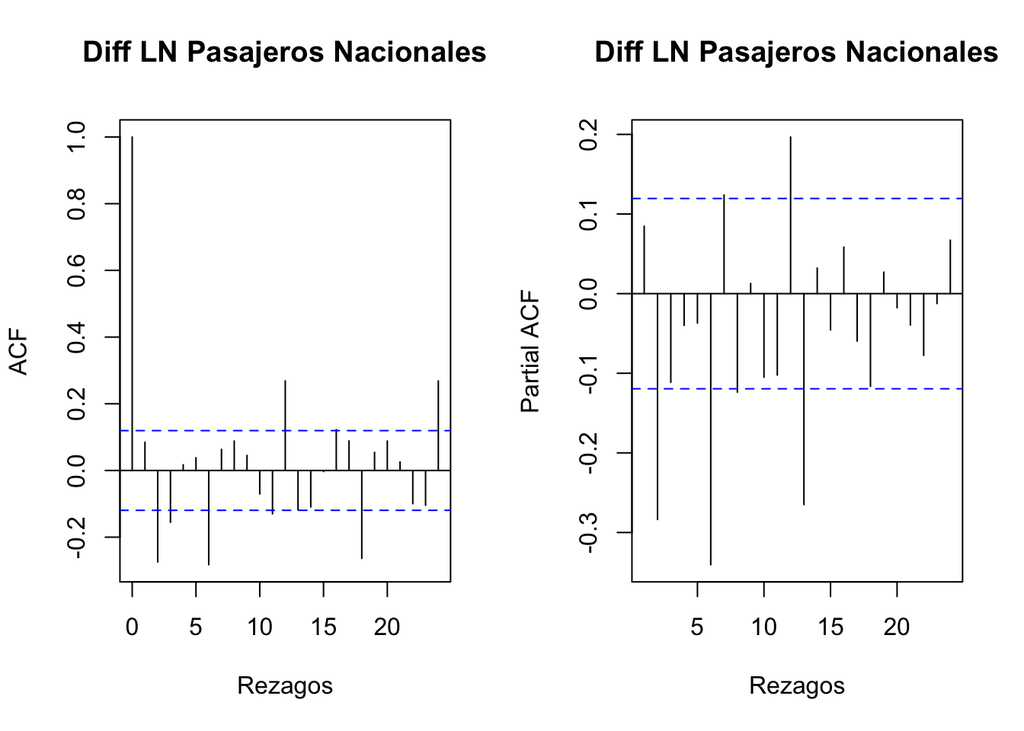

```r
par(mfrow=c(1,2))

acf(DLPax_Nal[2:270], lag.max = 24,
    xlab = "Rezagos",
    main = "Diff LN Pasajeros Nacionales")

pacf(DLPax_Nal[2:270], lag.max = 24,
     xlab = 'Rezagos',
     main = "Diff LN Pasajeros Nacionales")
```

```r
par(mfrow=c(1,1))
```

# Funciones que determinan el rezago optimo (que minimiza el criterio de Akaike)

Esta es una prueba mas formar respecto de la meta inspeccion grafica

```r
source("Lag_Opt_ARIMA_Exog.R")

# La funcion necesita de parametros definidos como:
  # Lag_Opt_ARIMA_Ex(p_max, d_max, q_max, X_t, Ex, Z_t){
  # p_max: Rezagos maximos a evaluar del componente AR
  # q_max: Rezagos maximos a evaluar del componente MA
  # d_max: Numero de diferencias evualadas
  # X_t: Serie de Tiempo modelada
  # Z_t: Vector o Matriz de variables exogenas
  # Ex: es indicador de que incluye variables exogenas (0 indica que no se incluyen, y 1 que si)
```

# Estimacion del proceso ARIMA(p, 1, q):

CON variables exogenas:

```r
Lag_Opt_ARIMA_Exog(p_max = 6, q_max = 6,
                   X_t = DLPax_Nal,
                   Ex = 1,
                   Z_t = cbind(D_Ene, D_Feb, D_Jul, D_Dic, D_Abr2020, D_Mar2020) )
```

```
##       Rezago p Rezago q       AIC Optimo
##  [1,]        1        1 -443.1001      0
##  [2,]        1        2 -448.6140      0
##  [3,]        1        3 -450.7637      0
##  [4,]        1        4 -448.1945      0
##  [5,]        1        5 -472.6082      0
##  [6,]        1        6 -484.2993      0
##  [7,]        2        1 -443.0225      0
##  [8,]        2        2 -502.8146      0
##  [9,]        2        3 -449.4591      0
## [10,]        2        4 -549.3594      0
## [11,]        2        5 -537.3119      0
## [12,]        2        6 -483.6920      0
## [13,]        3        1 -458.0751      0
## [14,]        3        2 -539.6605      0
```

[output cut: 22 more lines]

Estimacion:

```r
ARMA_Ex_DLPax_Nal <- arima(DLPax_Nal, order = c(5, 0, 4),
                           xreg = cbind(D_Ene, D_Feb, D_Jul, D_Dic, D_Abr2020, D_Mar2020),
                           method = "ML")
ARMA_Ex_DLPax_Nal
```

```
##
## Call:
## arima(x = DLPax_Nal, order = c(5, 0, 4), xreg = cbind(D_Ene, D_Feb, D_Jul, D_Dic,
##     D_Abr2020, D_Mar2020), method = "ML")
##
## Coefficients:
##          ar1     ar2      ar3      ar4     ar5     ma1      ma2      ma3
##       0.2771  0.9983  -0.2728  -1.0002  0.2754  0.0114  -0.9858  -0.0223
## s.e.  0.0878  0.0042   0.0854   0.0017  0.0858  0.0518   0.0742   0.0225
##          ma4  intercept    D_Ene    D_Feb   D_Jul    D_Dic  D_Abr2020
##       0.9761     0.0193  -0.2912  -0.1135  0.3362  -0.0030    -1.9757
## s.e.  0.0329     0.0082   0.0233   0.0240  0.0228   0.0235     0.0957
##       D_Mar2020
##         -0.4528
## s.e.     0.0870
##
## sigma^2 estimated as 0.005812:  log likelihood = 316.02,  aic = -598.04
```

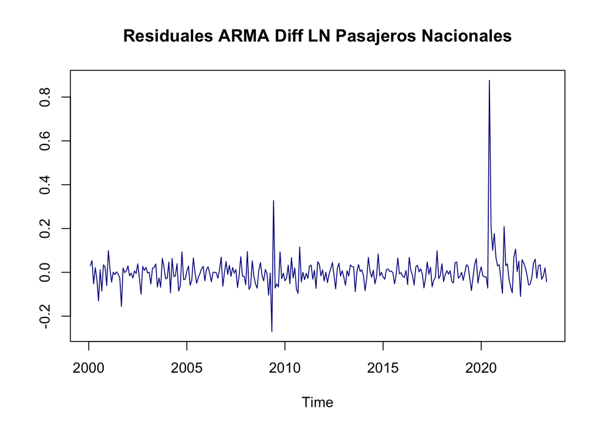

```r
plot(ARMA_Ex_DLPax_Nal$residuals,
     ylab = "",
     main = "Residuales ARMA Diff LN Pasajeros Nacionales",
     col = "darkblue")
```

# Nueva Estimacion del proceso ARIMA(p, 1, q):

CON variables exogenas por ESTACIONALIDAD rezagos optimos:

```r
Lag_Opt_ARIMA_Exog(p_max = 6, q_max = 6,
                   X_t = DLPax_Nal,
                   Ex = 1,
                   Z_t = cbind(D_Ene, D_Feb, D_Jul, D_Dic, D_Mar2020, D_Abr2020, D_Jun2020, D_Jul2020, D_Mar2021))
```

```
##       Rezago p Rezago q       AIC Optimo
##  [1,]        1        1 -561.4867      0
##  [2,]        1        2 -561.4327      0
##  [3,]        1        3 -573.7566      0
##  [4,]        1        4 -593.7144      0
##  [5,]        1        5 -600.6879      0
##  [6,]        1        6 -609.8023      0
##  [7,]        2        1 -561.8333      0
##  [8,]        2        2 -570.3672      0
##  [9,]        2        3 -621.3838      0
## [10,]        2        4 -615.1356      0
## [11,]        2        5 -685.4830      0
## [12,]        2        6 -684.7904      0
## [13,]        3        1 -540.7461      0
## [14,]        3        2 -568.3680      0
```

[output cut: 22 more lines]

```r
# Estimacion:

ARMA_Ex_DLPax_Nal_2 <- arima(DLPax_Nal, order = c(6, 0, 6),
                             xreg = cbind(D_Ene, D_Feb, D_Jul, D_Dic, D_Mar2020, D_Abr2020, D_Jun2020, D_Jul2020, D_Mar2021),
                             method = "ML")
ARMA_Ex_DLPax_Nal_2
```

```
##
## Call:
## arima(x = DLPax_Nal, order = c(6, 0, 6), xreg = cbind(D_Ene, D_Feb, D_Jul, D_Dic,
##     D_Mar2020, D_Abr2020, D_Jun2020, D_Jul2020, D_Mar2021), method = "ML")
##
## Coefficients:
##          ar1      ar2     ar3      ar4     ar5      ar6      ma1      ma2
##       0.0026  -0.0015  0.0026  -0.0008  0.0051  -0.9971  -0.0309  -0.0621
## s.e.  0.0045   0.0049  0.0070   0.0048  0.0043   0.0024   0.0378   0.0292
##           ma3      ma4      ma5     ma6  intercept    D_Ene    D_Feb   D_Jul
##       -0.0863  -0.0025  -0.0486  0.9532     0.0203  -0.1230  -0.1696  0.1436
## s.e.   0.0325   0.0345   0.0379  0.0367     0.0040   0.1009   0.0167  0.0992
##         D_Dic  D_Mar2020  D_Abr2020  D_Jun2020  D_Jul2020  D_Mar2021
##       -0.0001    -0.4714    -1.9748     0.8921     0.4998     0.1747
## s.e.   0.0173     0.0505     0.0500     0.0526     0.0519     0.0497
##
## sigma^2 estimated as 0.002394:  log likelihood = 436.71,  aic = -827.42
```

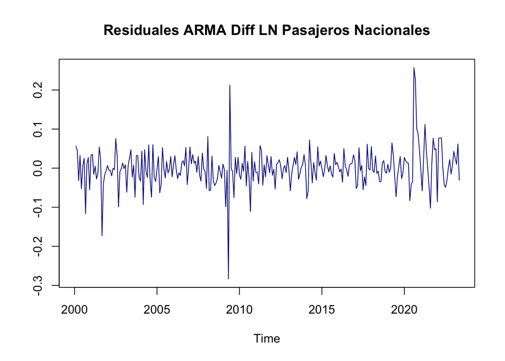

```r
plot(ARMA_Ex_DLPax_Nal_2$residuals,
     ylab = "",
     main = "Residuales ARMA Diff LN Pasajeros Nacionales",
     col = "darkblue")
```

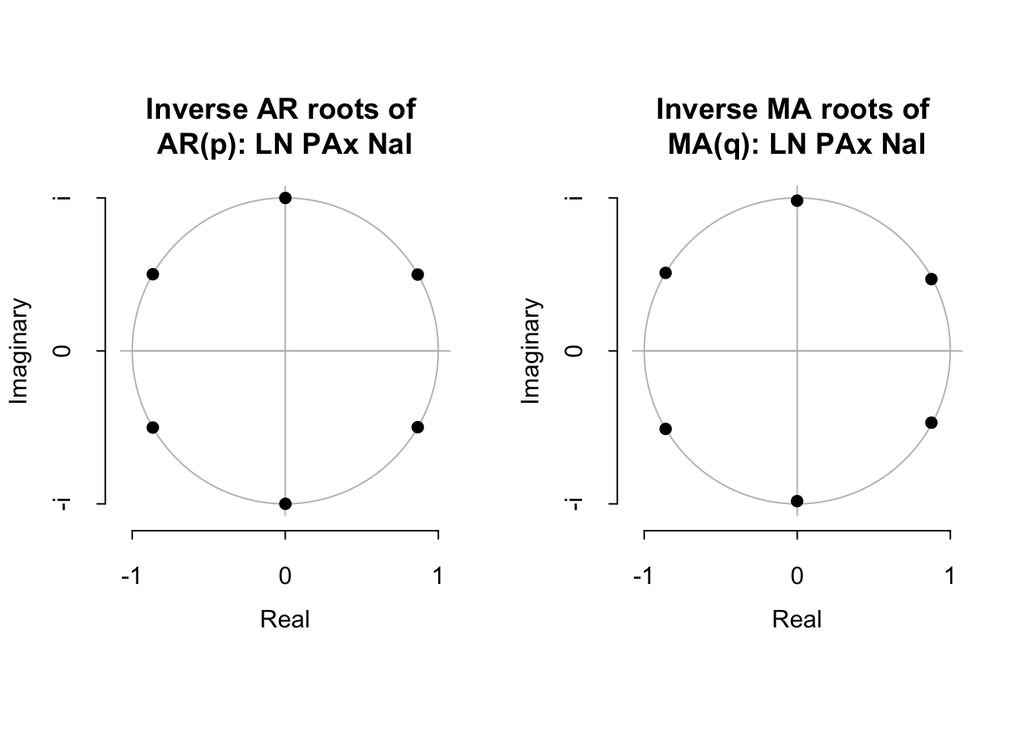

```r
#

par(mfrow=c(1,2))

plot.armaroots(arroots(ARMA_Ex_DLPax_Nal_2),
               main="Inverse AR roots of \nAR(p): LN PAx Nal")

plot.armaroots(maroots(ARMA_Ex_DLPax_Nal_2),
               main="Inverse MA roots of \nMA(q): LN PAx Nal")
```

```r
par(mfrow=c(1,1))
```